# Optimal Unwind: Weekly vs Monthly

Pritam Dalal

3/9/2019

The purpose of this analysis is to determine the optimal loss-trigger level. We consider all four combinations of monthly/weekly combined with delta-hedged/naked.

We consider all underlyings combined as well as each underlying individually.

### Data Integrity Check - Comparing to Scaled PNLs

As an initial sanity check, let’s make sure that the unmanaged sharpe are the same as using the scaled PNLs directly. For the naked positions, there should be a small discrepancy with the naked positions because the risk management code assumes a small delta-hedge on day-one to make the positions delta neutral on day-one.

There is also a discrepany with the delta hedged strategies, which I don’t understand. But the discrepancy seems to be samll so I’m not going to worry about it for now.

##### weekly delta-hedged (1.23)

```
## # A tibble: 1 x 4
##   loss_trigger avg_pnl sd_pnl sharpe
##          <dbl>   <dbl>  <dbl>  <dbl>
## 1         1000    1.78   22.1   1.27
```

##### monthly delta-hedged (0.78)

```
## # A tibble: 1 x 4
##   loss_trigger avg_pnl sd_pnl sharpe
##          <dbl>   <dbl>  <dbl>  <dbl>
## 1         1000    2.12   41.8  0.805
```

##### weekly naked (0.49)

```
## # A tibble: 1 x 4
##   loss_trigger avg_pnl sd_pnl sharpe
##          <dbl>   <dbl>  <dbl>  <dbl>
## 1         1000    1.28   36.9  0.550
```

##### monthly naked (0.13)

```
## # A tibble: 1 x 4
##   loss_trigger avg_pnl sd_pnl sharpe
##          <dbl>   <dbl>  <dbl>  <dbl>
## 1         1000    1.19   85.1  0.223
```

### Data-Integrity: Breach Count by Loss-Trigger

As another sanity check, we consider the number of breaches for each loss trigger level. The results make sense; here are some observations:

1. As the loss-trigger increases, there are less breaches.
2. For a given loss-trigger level, there are more breaches for naked strategies than for delta-hedged strategies, which is because of the greater PNL variability of those strategies.
3. For very low loss-trigger levels, the number of breaches is about the same for delta-hedged and naked.

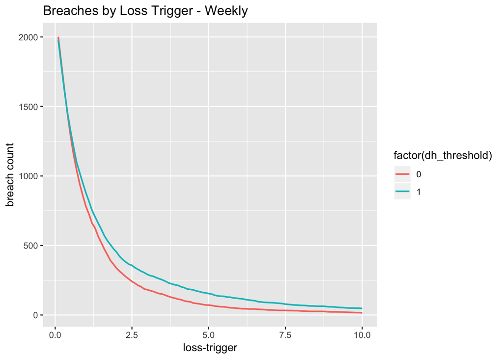

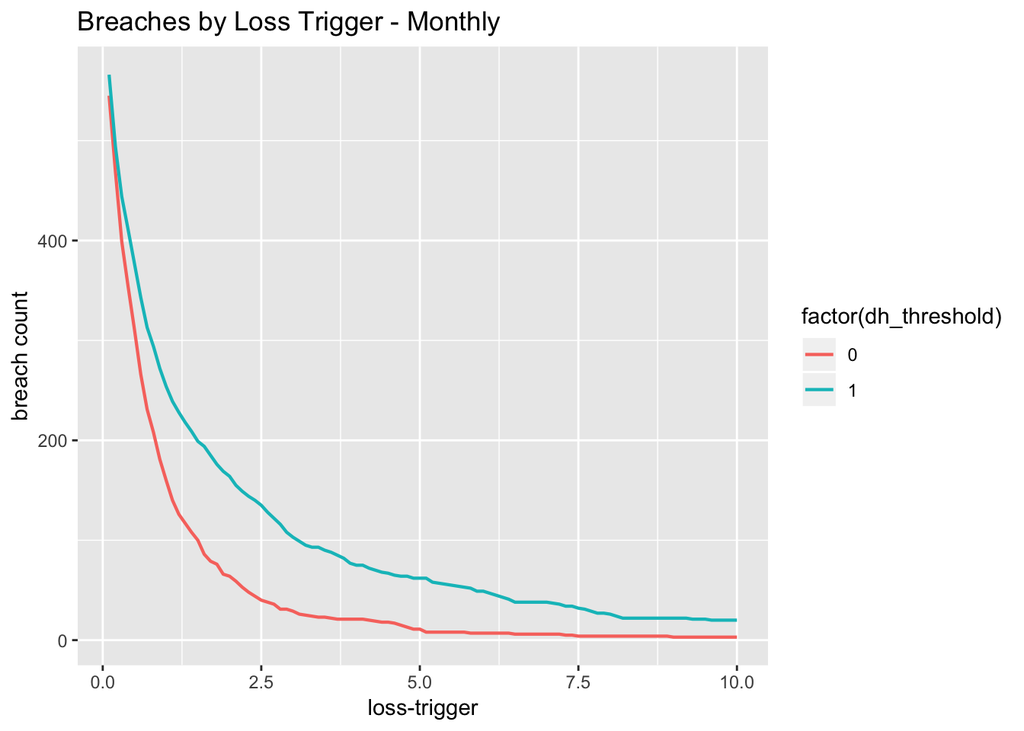

Finally, lets make sure that the breach counts were zero for the loss-trigger=1000.

```r
df_breach_count_weekly %>% filter(loss_trigger == 1000)
```

```
## # A tibble: 2 x 3
## # Groups:   dh_threshold [2]
##   dh_threshold loss_trigger breach_count
##          <dbl>        <dbl>        <int>
## 1            0         1000            0
## 2            1         1000            0
```

```r
df_breach_count_monthly %>% filter(loss_trigger == 1000)
```

```
## # A tibble: 2 x 3
## # Groups:   dh_threshold [2]
##   dh_threshold loss_trigger breach_count
##          <dbl>        <dbl>        <int>
## 1            0         1000            0
## 2            1         1000            0
```

### All Underlyings Combined

In this section, we consider the strategy of combining all underlyings together and then check for the optimal loss trigger level.

It seems clear that the only strategy for which a loss-trigger seems to make an impact is on the weekly naked strategy. It makes sense to me that when you are delta-hedging, a loss-trigger doesn’t make that much of an impact (meaning it can only really hurt you) because the delta-hedging itself is doing most of the risk management for you.

I’m not sure why the monthly naked strategy doesn’t show a similar pattern - perhaps it’s because there isn’t enough data.

#### weekly delta-hedged

```r
# weekly delta-hedged
df_sharpe_weekly %>%
    filter(dh_threshold == 0) %>%
    filter(sharpe == max(sharpe)) %>%
    select(dh_threshold, loss_trigger, sharpe)
```

```
## # A tibble: 1 x 3
##   dh_threshold loss_trigger sharpe
##          <dbl>        <dbl>  <dbl>
## 1            0         1000   1.27
```

#### monthly delta-hedged

```r
# monthly delta-hedged
df_sharpe_monthly %>%
    filter(dh_threshold == 0) %>%
    filter(sharpe == max(sharpe)) %>%
    select(dh_threshold, loss_trigger, sharpe)
```

```
## # A tibble: 1 x 3
##   dh_threshold loss_trigger sharpe
##          <dbl>        <dbl>  <dbl>
## 1            0         1000  0.805
```

#### weekly naked

```r
# weekly naked
df_sharpe_weekly %>%
    filter(dh_threshold == 1) %>%
    filter(sharpe == max(sharpe)) %>%
    select(dh_threshold, loss_trigger, sharpe)
```

```
## # A tibble: 1 x 3
##   dh_threshold loss_trigger sharpe
##          <dbl>        <dbl>  <dbl>
## 1            1          2.1  0.654
```

#### monthly naked

```r
# monthly naked
df_sharpe_monthly %>%
    filter(dh_threshold == 1) %>%
    filter(sharpe == max(sharpe)) %>%
    select(dh_threshold, loss_trigger, sharpe)
```

```
## # A tibble: 1 x 3
##   dh_threshold loss_trigger sharpe
##          <dbl>        <dbl>  <dbl>
## 1            1         1000  0.223
```

#### weekly naked (average of top-5)

Instead of looking at just the single best loss-trigger level, it’s more robust to take the average of the top 5 unwind levels.

```r
# weekly naked - average of top 5 loss-trigger levels.
df_sharpe_weekly %>%
    filter(dh_threshold == 1) %>%
    top_n(5, sharpe) %>%
    .$loss_trigger %>%
    mean()
```

```
## [1] 2.48
```

#### visualization

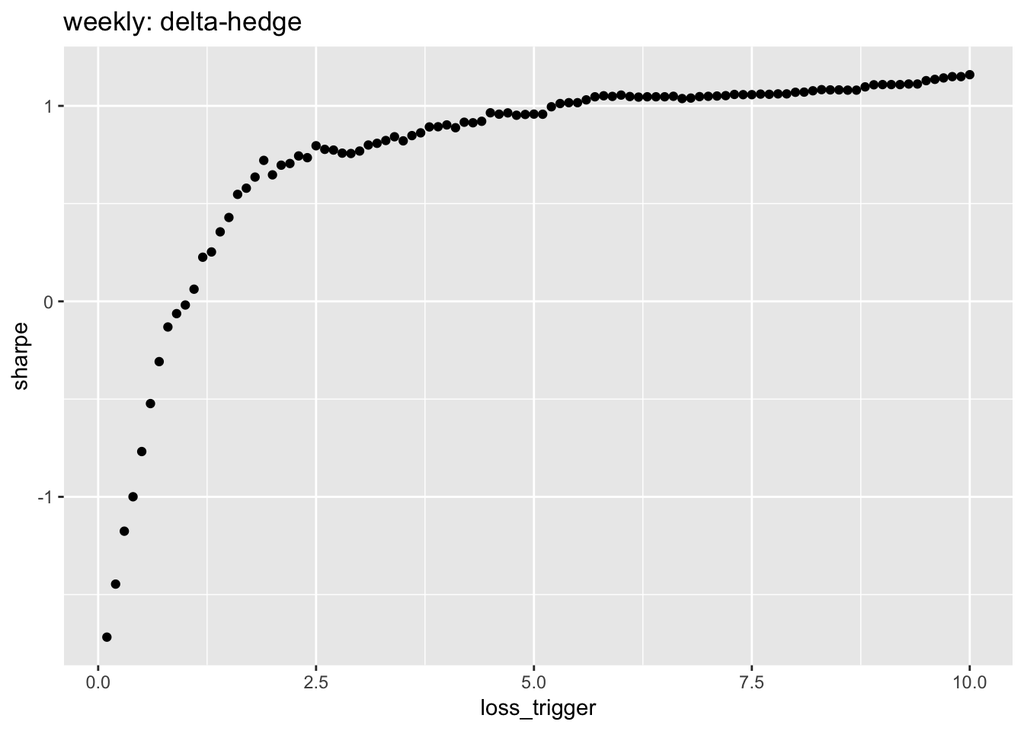

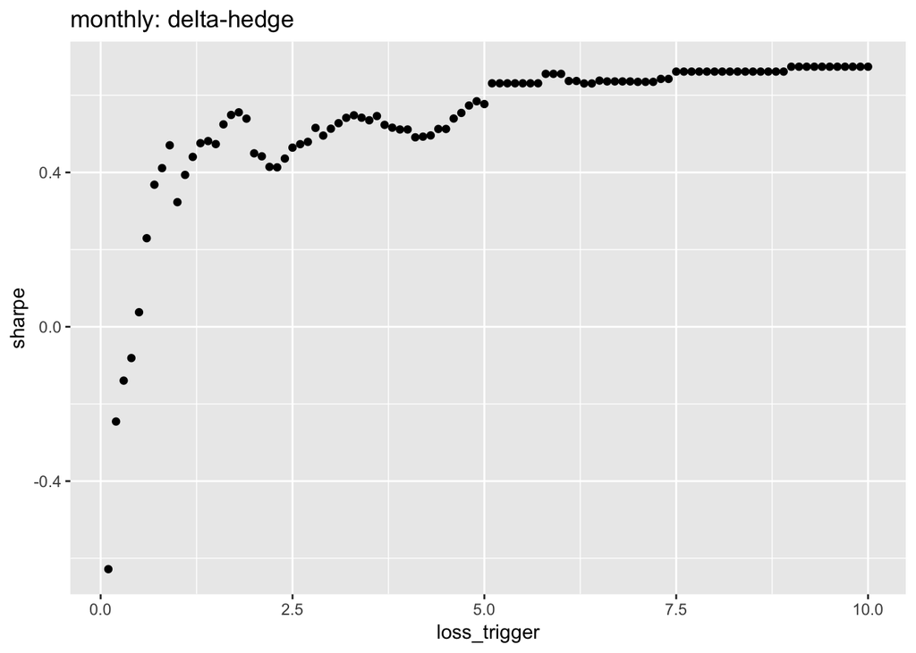

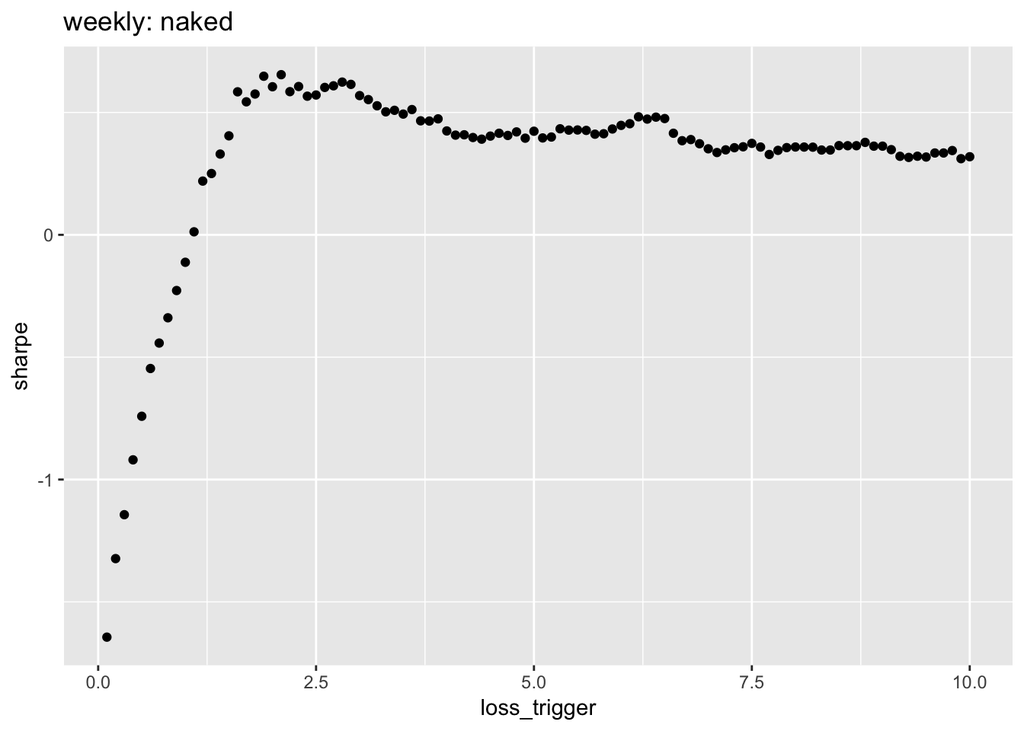

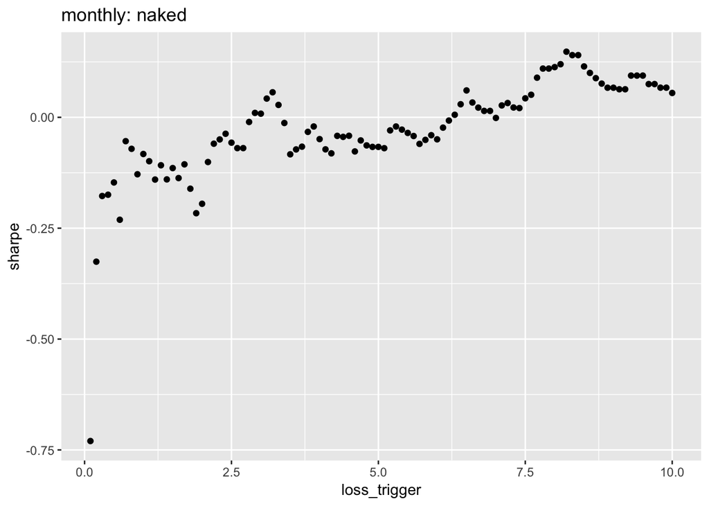

The optimal unwind level for the weekly naked strategy is when the loss reache 2.25 - 2.50 of initial premium.

### Underlyings Individually

In the previous section we saw that the weekly naked strategy was the only one that seemed to be positively impacted by a loss-trigger unwind strategy.

So as we examine the underlyings individaully, we will largely focus on the two naked strategies, so as to not overly clutter the analysis with data.

#### Average Optimal Loss-Trigger

In this subsection, for each of the four tenor/hedging combinations, we calcualte the average optimal loss-trigger, where the average is taken over the underlyings.

```r
df_opt_loss_trigger %>%
    group_by(tenor, hedge) %>%
    summarize(
        opt_loss_trigger = mean(opt_loss_trigger)
    )
```

```
## # A tibble: 4 x 3
## # Groups:   tenor [?]
##   tenor   hedge opt_loss_trigger
##   <chr>   <chr>            <dbl>
## 1 monthly dh                5.25
## 2 monthly naked             4.07
## 3 weekly  dh                7.51
## 4 weekly  naked             4.24
```

The delta-hedge optimals are lower than I expected, but I have to admit that it’s hard for me to clearly interpret these results. It’s good to see that the delta-hedge averages are higher than the naked averages.

#### Optimal Level for each Underlying

```r
df_opt_loss_trigger %>%
    filter(tenor == "weekly") %>%
    filter(hedge == "naked") %>%
    arrange(opt_loss_trigger)
```

```
## # A tibble: 12 x 4
##    tenor  hedge underlying opt_loss_trigger
##    <chr>  <chr> <chr>                 <dbl>
##  1 weekly naked QQQ                    1.24
##  2 weekly naked FXI                    1.38
##  3 weekly naked IWM                    1.6
##  4 weekly naked SPY                    1.9
##  5 weekly naked DIA                    2.28
##  6 weekly naked GLD                    2.55
##  7 weekly naked EEM                    2.84
##  8 weekly naked EWZ                    4.12
##  9 weekly naked USO                    5.77
## 10 weekly naked SLV                    8
## 11 weekly naked XLE                    9.35
## 12 weekly naked GDX                    9.8
```

```r
df_opt_loss_trigger %>%
    filter(tenor == "weekly") %>%
    filter(hedge == "dh") %>%
    arrange(opt_loss_trigger)
```

```
## # A tibble: 12 x 4
##    tenor  hedge underlying opt_loss_trigger
##    <chr>  <chr> <chr>                 <dbl>
##  1 weekly dh    SPY                    1.2
##  2 weekly dh    QQQ                    2.56
##  3 weekly dh    SLV                    6.8
##  4 weekly dh    EWZ                    7.05
##  5 weekly dh    DIA                    7.95
##  6 weekly dh    USO                    8.55
##  7 weekly dh    GLD                    8.6
##  8 weekly dh    GDX                    9.15
##  9 weekly dh    IWM                    9.4
## 10 weekly dh    XLE                    9.45
## 11 weekly dh    FXI                    9.65
## 12 weekly dh    EEM                    9.8
```

```r
df_opt_loss_trigger %>%
    filter(tenor == "monthly") %>%
    filter(hedge == "naked") %>%
    arrange(opt_loss_trigger)
```

```
## # A tibble: 12 x 4
##    tenor   hedge underlying opt_loss_trigger
##    <chr>   <chr> <chr>                 <dbl>
##  1 monthly naked DIA                    0.5
##  2 monthly naked SPY                    0.6
##  3 monthly naked EWZ                    0.7
##  4 monthly naked FXI                    1.48
##  5 monthly naked XLE                    2.38
##  6 monthly naked GLD                    3.2
##  7 monthly naked GDX                    4.69
##  8 monthly naked IWM                    5.73
##  9 monthly naked EEM                    6
## 10 monthly naked SLV                    6.9
## 11 monthly naked USO                    8
## 12 monthly naked QQQ                    8.65
```

```r
df_opt_loss_trigger %>%
    filter(tenor == "monthly") %>%
    filter(hedge == "dh") %>%
    arrange(opt_loss_trigger)
```

```
## # A tibble: 12 x 4
##    tenor   hedge underlying opt_loss_trigger
##    <chr>   <chr> <chr>                 <dbl>
##  1 monthly dh    GDX                    0.56
##  2 monthly dh    DIA                    1.64
##  3 monthly dh    SPY                    1.74
##  4 monthly dh    FXI                    2.9
##  5 monthly dh    EEM                    5.35
##  6 monthly dh    GLD                    6.05
##  7 monthly dh    SLV                    6.19
##  8 monthly dh    EWZ                    7.01
##  9 monthly dh    USO                    7.35
## 10 monthly dh    QQQ                    7.55
## 11 monthly dh    IWM                    7.9
## 12 monthly dh    XLE                    8.75
```

#### Visualizing the Naked Strategies

In this section we examine the faceted graphs of sharpe by loss trigger, so that we can examine the underlyings individually. All the graphs are pretty noisy, especially the monthly ones. However, I do hold out some hope that there is an optimal loss unwind strategy for monthlys also.

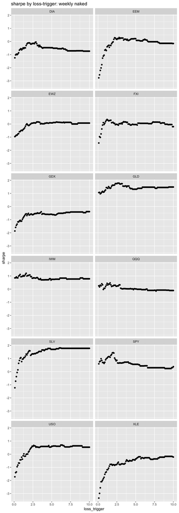

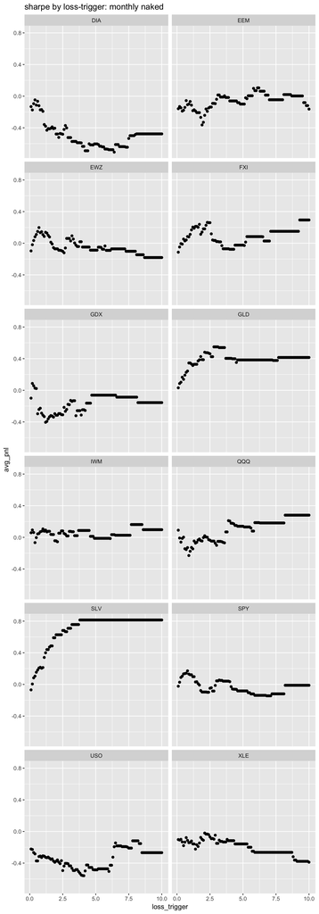

#### Weekly Naked: Top Half vs Bottom Half

In this section we focus on the weekly naked strategy - the only one that shows significant positive impact from a loss-trigger unwind. I hypothesized that the optimal loss trigger would be different for top-performers vs bottom performer. And this does not seem to be the case. Both have an optimal unwind areound the 2.5x level.

```
## [1] "TOP HALF - optimal loss trigger: 2.16"
```

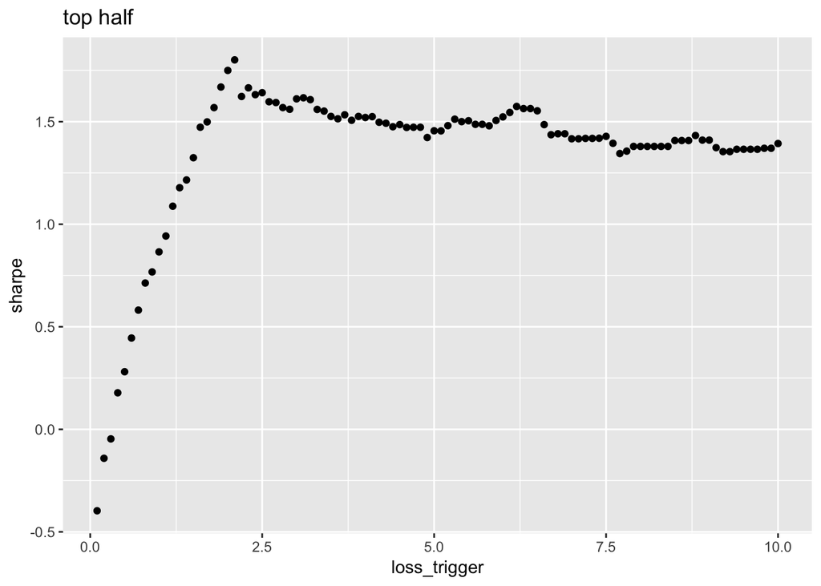

```
## [1] "BOTTOM HALF - optimal loss trigger: 2.38"
```

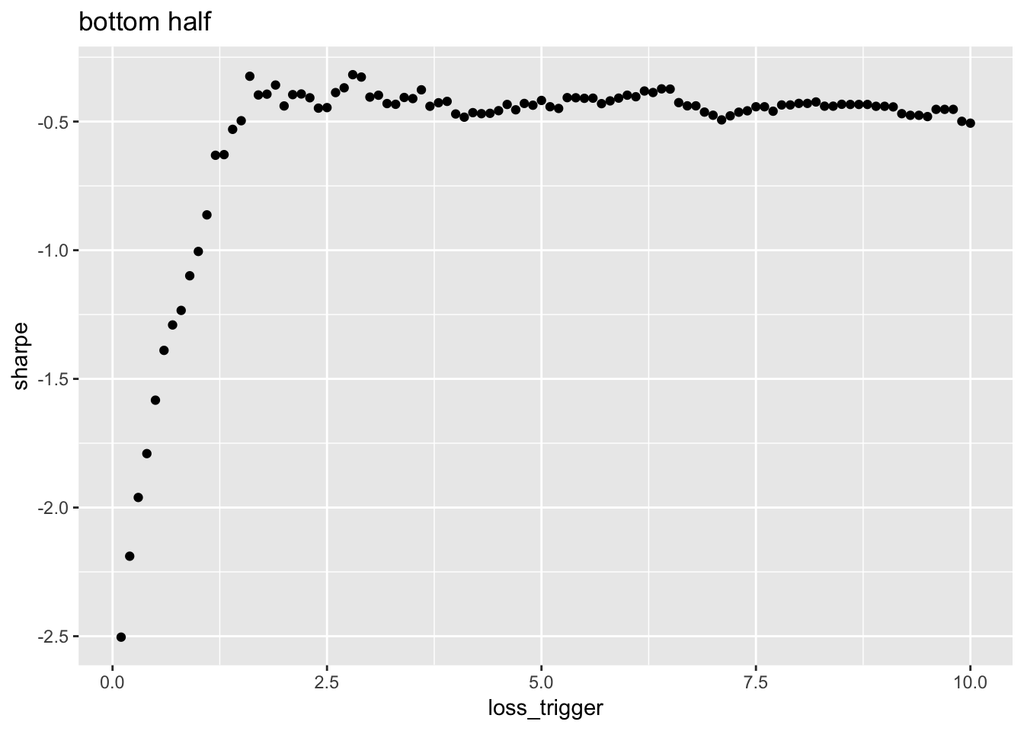

### Conclusions

(Written on 3/14/2019) I have to admit that I’m a bit discourage by these results. When I did the SPY analysis for Leigh, it seemed like I could significantly improve naked option selling performance with a loss-trigger strategy, and that I could even rival the performance of delta-hedging. However, with the large data set, even using an optimal unwind level, there is only a marginal improvement on performance relative to doing nothing (for all underlyings combined the sharpe goes from 0.55 to 0.65, not a massive jump).

One encouraging result is that optimal loss trigger for naked weekly option selling is 2.0-2.5, which is the same thing that I found in the SPY analysis, which feels good.

It’s also disappointing that there is no obvious optimal loss-trigger for naked monthly option selling. So I don’t have a good rule of thumb to apply to my current trading. All fingers seems to point to moving to weekly options, but this will also quadruple what I pay on commissions. It’s hard to know if the performance is enough to compensate for this.

However, the sitout strategy for weeklys is much more tractible, and makes strong intuitive sense, which I also like.

Based on the analysis so far, I leaning towards moving to a weekly strategy, with a 2.5x loss-trigger unwind. I’ll try running that for a while as I gather more information.